25/12/2023

STATISTICAL SOFTWARE R and SAS: Final Practice

By Oriol Segarra y Nabil EL Bachiri

Problem Statement

Europe is affected by climate change and its effects are not only perceived on earth. European water bodies (lakes, rivers and oceans and seas of the continent) are also affected. Given that there is more water than land on the planet’s surface, it is not surprising that the warming of the oceans has accounted for about 93 % of the global warming since the 1950s.

This warming occurs as a result of the increase in greenhouse gas emissions, especially carbon dioxide, which in turn trap more and more solar energy within the atmosphere. Most of this trapped heat is eventually stored in the oceans, which affects the temperature and the circulation of water. Sea surface temperatures on European coasts are rising more rapidly than those in the world oceans. Water temperature represents one of the most important regulatory elements of marine life, so that temperature increases are already causing major changes under the surface of the water (www.eea.europa.eu)

In the file data frame sea_temperature.xls the temperature is displayed (grados centígrados) of sea water at different depths (0, -20, -50, -80m) from 2000 to 2017, measured at the Estartit observation point on the Costa Brava (1 mile east of the Medes Islands (Girona); coordinates: 4203 Ń, 315 É). This table shows the temperatures of each month by depth and the temperatures of each month for a period of about 30 years. The average temperatures of the periods are also presented. The description of this data can be found in the IDESCAT link: https://www.idescat.cat/pub/?id=aec&n=218&t=2000

The objective of this practice is to contribute to the study of climate change, especially that produced in the last 30 years, through the use of real data. We will thus proceed to carry out a study as complete as possible (descriptive, graphical, functions, bookstore of R) on the change of the sea temperature by depth for the different years and months studied, as well as in the different depths and their comparison with the previous periods. Different functions will be performed as described in the following different sections.

Exercise 1

Section A

Import the study data (data frame sea_temperature.xls) and place it in a data frame with name sea.deep. Name the variables according to the specifications in the data set and place labels describing units and what each variable and case is (years, months, depth, etc.). You should place it properly according to the format of the data.

**Answer**

```r
#Exercici 1a
library(rvest)
library(xml2)
library(dplyr)
library(tidyr)

scrape_and_process_data <- function(years) {
  base_url <- "https://www.idescat.cat/indicadors/?id=aec&n=15196&t="

  # Function to scrape data
  scrape_data_for_year <- function(year) {
    url <- paste0(base_url, year, "00")
    webpage <- read_html(url)
    tables <- html_nodes(webpage, "table.ApartNum.xs.Cols5")
    data <- html_table(tables, fill = TRUE)
    captions <- html_nodes(webpage, "table.ApartNum.xs.Cols5 > caption") %>%
      html_text()
    names(data) <- captions

    # Drop rows containing "Font" or "Nota"
    data <- lapply(data, function(table) {
      drop_rows <- grepl("Font|Nota", table[[1]])
      table[!drop_rows, ]
    })

    return(data)
  }

  # Function to process each dataset
  process_tibble <- function(tibble, year) {
    if (tibble[1, 1] == "") {
      tibble[1, 1] <- paste("Any", year)
      tibble[2:14, 1] <- sapply(tibble[2:14, 1], function(month) paste(month, year, sep="-"))
    } else {
      period <- tibble[1, 1]
      tibble[2:14, 1] <- sapply(tibble[2:14, 1], function(month) paste(month, period, sep="-"))
    }
    return(tibble)
  }

  all_data <- lapply(years, scrape_data_for_year)

  # Process and reshape data
  all_data_long_format <- data.frame()

  for (i in seq_along(all_data)) {
    pair <- all_data[[i]]
    year <- years[i]

    processed_pair <- lapply(pair, function(tib) process_tibble(tib, year))

    for (j in seq_along(processed_pair)) {
      tibble <- processed_pair[[j]]
      depths <- as.character(tibble[1, -1])
      colnames(tibble)[1] <- "Month"
      colnames(tibble)[-1] <- paste0("Depth_", depths)
      tibble <- tibble[-1, ]

      reshaped <- tibble %>%
        pivot_longer(cols = starts_with("Depth_"), names_to = "Depth", values_to = "Temperature") %>%
        mutate(Year = year, Type = ifelse(j == 1, "Current Year", "Historical"))

      reshaped$Month <- rep(tibble$Month, each = length(depths))

      all_data_long_format <- rbind(all_data_long_format, reshaped)
    }
  }

  return(as.data.frame(all_data_long_format))
}

# Usage
years <- 2000:2022
sea.deep <- scrape_and_process_data(years)
head(sea.deep, 10)
```

```
##          Month     Depth Temperature Year         Type
## 1   Gener-2000   Depth_0        12,9 2000 Current Year
## 2   Gener-2000 Depth_-20        12,9 2000 Current Year
## 3   Gener-2000 Depth_-50        12,8 2000 Current Year
## 4   Gener-2000 Depth_-80        12,7 2000 Current Year
## 5  Febrer-2000   Depth_0        12,7 2000 Current Year
## 6  Febrer-2000 Depth_-20        12,7 2000 Current Year
## 7  Febrer-2000 Depth_-50        12,6 2000 Current Year
## 8  Febrer-2000 Depth_-80        12,4 2000 Current Year
## 9    Març-2000   Depth_0        12,8 2000 Current Year
## 10   Març-2000 Depth_-20        12,7 2000 Current Year
```

The function scrape_and_process_data begins by defining the base URL for the Idescat website and establishes a range of years (2000 to 2022) for which the data is to be collected. Within the function, a custom (inner) function, scrape_data_for_year, is created to navigate through the website for each specified year. This function extracts relevant tables from the webpage and cleanses the data by removing rows where the first column contains specific keywords (‘Font’ and ‘Nota’). This ensures that only relevant data is retained, making the dataset more accurate and useful.

The scraped data is systematically organized into a list, with each element corresponding to a year. Each list element contains one or more data frames (tibbles), each named with a caption extracted from the website. This organization provides a clear structure to the dataset, facilitating subsequent processing and analysis.

The function then introduces another (inner) function, process_tibble, dedicated to refining the structure of these tibbles. This function addresses potential inconsistencies, such as empty cells in the first row or column. It modifies the first column of each tibble to include the year, appending it to each month or period mentioned. This step is crucial as it ensures that each data point is correctly timestamped, which is vital for accurate analysis after merging the data.

Subsequently, the function iteratively applies these functions to the data from each year, collating the results into a comprehensive dataset. The final segment of the function employs the dplyr and tidyr packages to transform this list of tibbles into a long format. This transformation is achieved using the pivot_longer function, which converts the data into a format more conducive for in-depth analysis. The outcome is a well-structured sea.deep data frame, with columns for Month, Depth, Temperature, Year, and Type. This format facilitates easier access and manipulation of the data for subsequent analytical tasks.

Section B

Use the function label of package Hmisc to tag variables (using the data frame sea.deep).

**Answer**

```r
#Exercici 1b
library(Hmisc)

# Assign labels to each column
label(sea.deep$Month) <- "Month and Year of Observation"
label(sea.deep$Depth) <- "Depth in meters (m)"
label(sea.deep$Temperature) <- "Sea Temperature in Celsius (°C)"
label(sea.deep$Year) <- "Year of Observation"
label(sea.deep$Type) <- "Type of Data (Current Year or Historical)"

# Check the labels
describe(sea.deep)
```

```
## sea.deep
##
##  5  Variables      2392  Observations
## --------------------------------------------------------------------------------
## Month : Month and Year of Observation
##        n  missing distinct
##     2392        0      494
##
## lowest : Abril-2000                 Abril-2001                 Abril-2002                 Abril-2003                 Abril-2004
## highest: Setembre-Període 1974-2010 Setembre-Període 1974-2011 Setembre-Període 1974-2012 Setembre-Període 1974-2013 Setembre-Període 1981-2010
## --------------------------------------------------------------------------------
## Depth : Depth in meters (m)
##        n  missing distinct
##     2392        0        4
##
## Value      Depth_-20 Depth_-50 Depth_-80   Depth_0
## Frequency        598       598       598       598
## Proportion      0.25      0.25      0.25      0.25
## --------------------------------------------------------------------------------
## Temperature : Sea Temperature in Celsius (°C)
##        n  missing distinct
##     2392        0      126
##
## lowest : 11,7 11,8 11,9 12,0 12,1, highest: 24,1 24,2 24,4 24,7 25,2
## --------------------------------------------------------------------------------
## Year : Year of Observation
##        n  missing distinct     Info     Mean      Gmd      .05      .10
##     2392        0       23    0.998     2011    7.655     2001     2002
##      .25      .50      .75      .90      .95
##     2005     2011     2017     2020     2021
##
## lowest : 2000 2001 2002 2003 2004, highest: 2018 2019 2020 2021 2022
## --------------------------------------------------------------------------------
## Type : Type of Data (Current Year or Historical)
##        n  missing distinct
##     2392        0        2
##
## Value      Current Year   Historical
## Frequency          1196         1196
## Proportion          0.5          0.5
## --------------------------------------------------------------------------------
```

Section C

Indicate the dimension of the data-frame and make a descriptive of the variables.

**Answer**

```r
#Exercici 1c

dim(sea.deep)
```

```
## [1] 2392    5
```

```r
sea.deep$Temperature <- as.numeric(sub(",", ".", sea.deep$Temperature))
summary(sea.deep)
```

```
##     Month              Depth            Temperature         Year
##  Length:2392        Length:2392        Min.   :11.70   Min.   :2000
##  Class1:labelled    Class1:labelled    1st Qu.:13.40   1st Qu.:2005
##  Class2:character   Class2:character   Median :14.60   Median :2011
##  Mode  :character   Mode  :character   Mean   :15.49   Mean   :2011
##                                        3rd Qu.:16.80   3rd Qu.:2017
##                                        Max.   :25.20   Max.   :2022
##      Type
##  Length:2392
##  Class1:labelled
##  Class2:character
##  Mode  :character
##
##
```

```r
str(sea.deep)
```

```
## 'data.frame':    2392 obs. of  5 variables:
##  $ Month      : 'labelled' chr  "Gener-2000" "Gener-2000" "Gener-2000" "Gener-2000" ...
##   ..- attr(*, "label")= chr "Month and Year of Observation"
##  $ Depth      : 'labelled' chr  "Depth_0" "Depth_-20" "Depth_-50" "Depth_-80" ...
##   ..- attr(*, "label")= chr "Depth in meters (m)"
##  $ Temperature: num  12.9 12.9 12.8 12.7 12.7 12.7 12.6 12.4 12.8 12.7 ...
##  $ Year       : 'labelled' int  2000 2000 2000 2000 2000 2000 2000 2000 2000 2000 ...
##   ..- attr(*, "label")= chr "Year of Observation"
##  $ Type       : 'labelled' chr  "Current Year" "Current Year" "Current Year" "Current Year" ...
##   ..- attr(*, "label")= chr "Type of Data (Current Year or Historical)"
```

As we can see, the data consists of 2392 rows and 5 columns. Columns: 1. Month: This first column indicates the period of the data in each row. It is a complex column, as there are 4 types of data in this column. We have data for each month in each year specifically (Gener-2000), on the other hand, we also have the annual average for each year. (Annual mean-2000), another different type of data is the monthly mean (only for one month) in an interval of years (Gener-Period 1974-1999) in this case is the average of all the months of January within that interval of years. Finally, we have the annual mean of a whole period (Annual mean-Period 1974-1999). 2. Depth: The Depth column indicates the depth at which the data in that row is taken. We have 4 different depths: 0 meters, -20 meters, -50 meters and -80 meters. This is why each date in the first column will be quadrupled, one for each depth value. 3. Temperature: the temperature column indicates the temperature of the water in each of the measurements, it is represented in degrees Celsius. 4. Year: The year indicates the year in which the observation was taken. 5. Type: This last column indicates the type of data we are dealing with. We see two different types: Current year for those rows in which the observation is punctual in a month and year or an average of a specific year, and, on the other hand, Historical for those rows with observations that represent a time interval, whether it is an average of a month in a period or an annual average over a range of years.

As demonstrated by the size of the data frame, it is very large, however, for each exercise, we will choose the data that interests us to carry out the exercise.

Section D

Represent by means of Boxplots the average temperatures by depth and year.

**Answer**

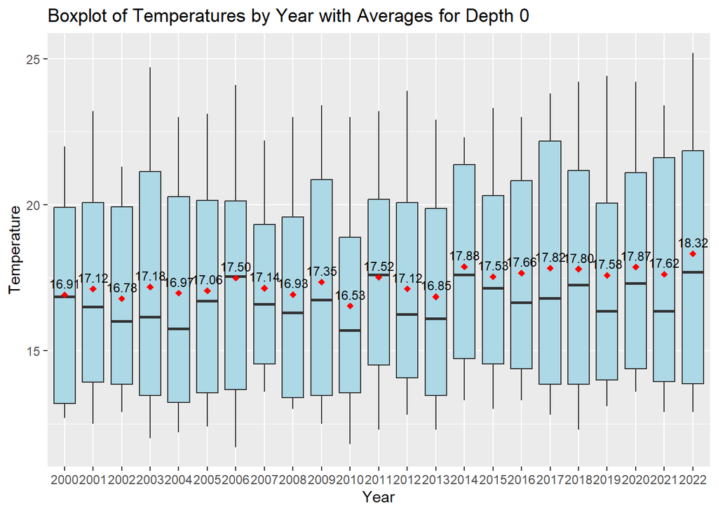

```r
#Exercici 1d

library(dplyr)

filter_sea_deep <- function(depth) {
  result <- sea.deep %>%
    filter(!grepl("Mitjana", Month), Depth == depth, Type == "Current Year") %>%
    select(-c(1, 2, 5)) %>%
    select(Year, everything())

  return(result)
}

sea_deep_0 <- filter_sea_deep("Depth_0")
sea_deep_20 <- filter_sea_deep("Depth_-20")
sea_deep_50 <- filter_sea_deep("Depth_-50")
sea_deep_80 <- filter_sea_deep("Depth_-80")

library(readr)
sea_deep_0$Temperature <- as.numeric(gsub(",", ".", sea_deep_0$Temperature))
sea_deep_20$Temperature <- as.numeric(gsub(",", ".", sea_deep_20$Temperature))
sea_deep_50$Temperature <- as.numeric(gsub(",", ".", sea_deep_50$Temperature))
sea_deep_80$Temperature <- as.numeric(gsub(",", ".", sea_deep_80$Temperature))


library(ggplot2)

plot_boxplot <- function(data, depth) {
  p <- ggplot(data, aes(x = as.factor(Year), y = Temperature)) +
    geom_boxplot(fill = "lightblue") +  # Cambiar el color de los boxplots a azul claro
    stat_summary(fun = mean, geom = "point", shape = 18, size = 2, color = "red", position = position_dodge(0.75)) +
    stat_summary(fun.data = mean_cl_normal, geom = "text", aes(label = sprintf("%.2f", ..y..)), vjust = -0.7,
                 size = 3, position = position_dodge(0.75)) +
    labs(title = paste("Boxplot of Temperatures by Year with Averages for Depth", depth), x = "Year", y = "Temperature")

  return(p)
}

plot_boxplot(sea_deep_0, "0")
```

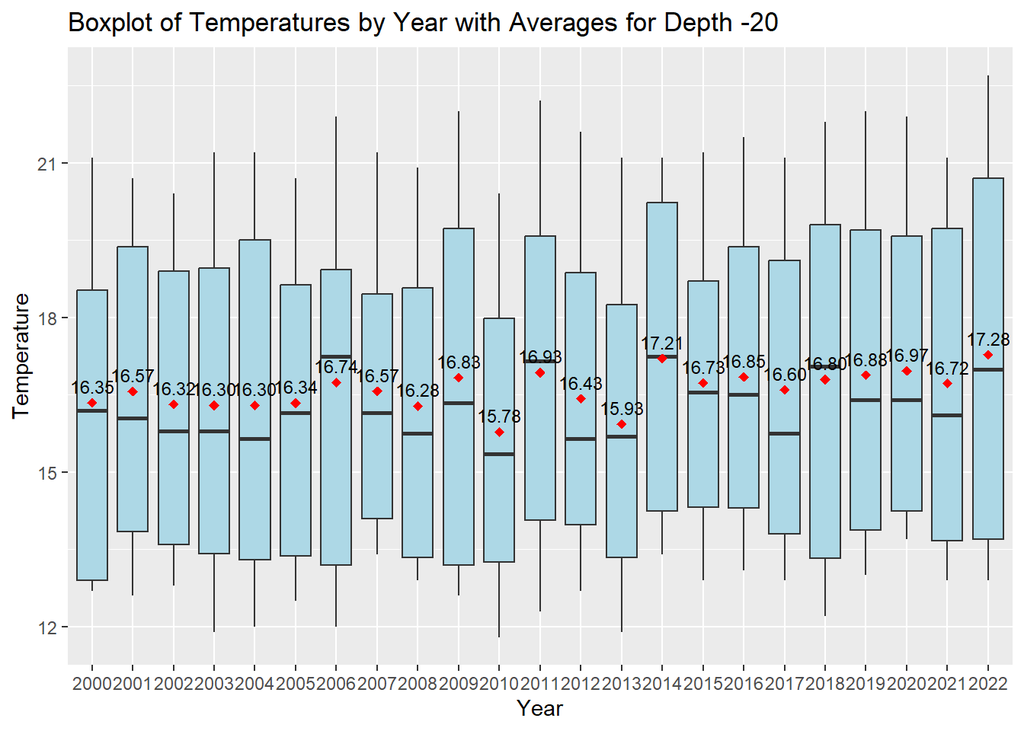

```r
plot_boxplot(sea_deep_20, "-20")
```

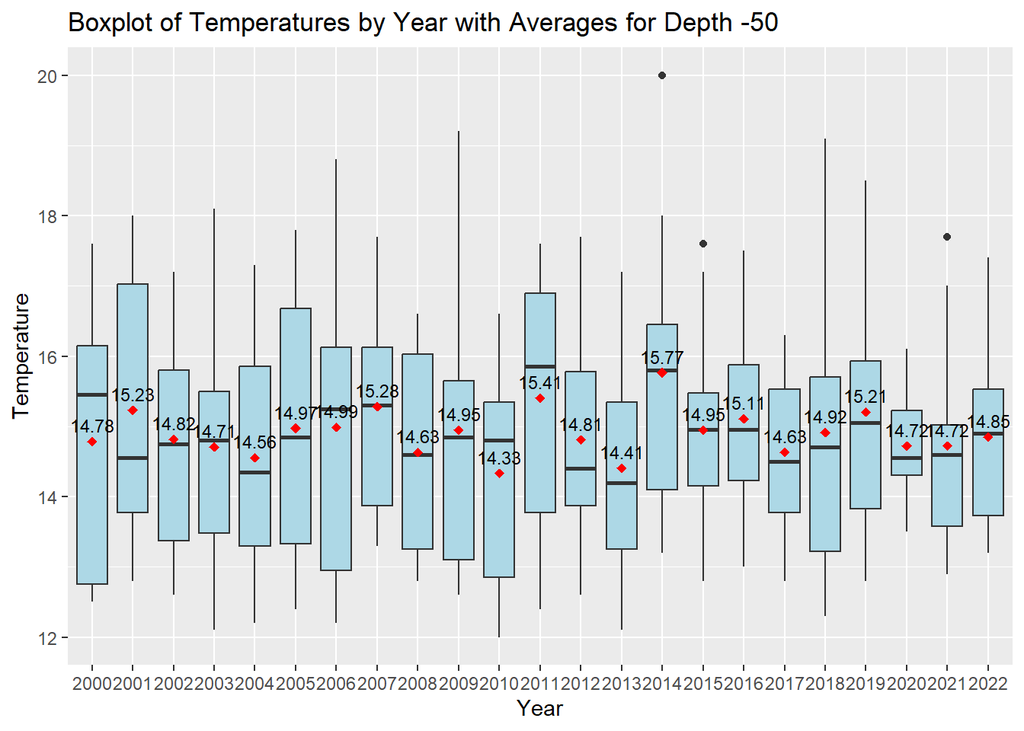

```r
plot_boxplot(sea_deep_50, "-50")
```

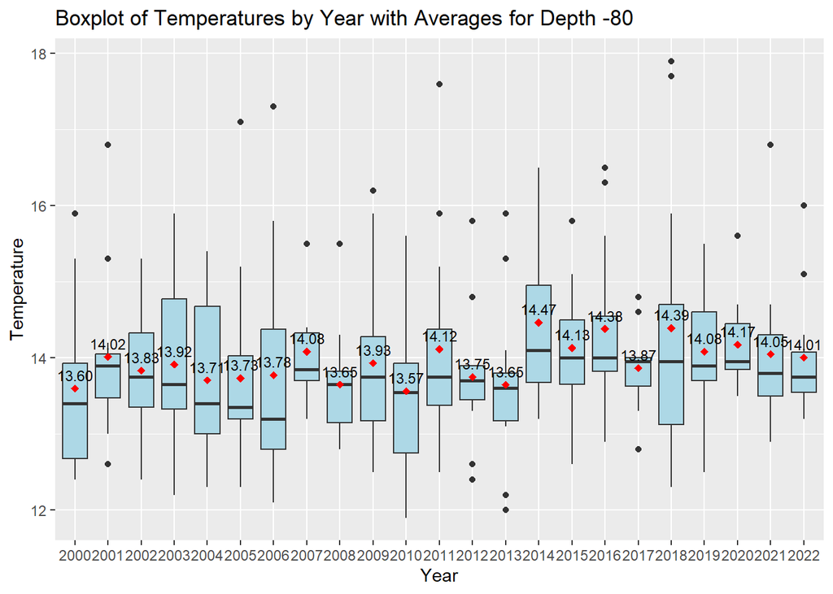

```r
plot_boxplot(sea_deep_80, "-80")
```

With these boxplots we can see the interquartile range, as well as the first quartile, the lower part of the boxplot, the third quartile, the upper part of the boxplot, the median represented as a line within each boxplot and, in addition, we have added the mean, represented with a red dot and its value. Outliers can also be observed, represented by black dots at the ends of each plot. The whiskers on the graphs are used to detect outliers, which cannot be greater than 150% of the interquartile range.

Comparing the 4 plots, we observe how the first two plots (depth_0 and depth_20), have wider boxplots than those of depth_50 and depth_80, which is completely logical since the range of temperature values in shallower waters must vary more than in deeper waters, due to the effect of the sun or atmospheric heat.

Section E

Calculate the mean, median, standard deviation and the interquartile range for each of the previous groups (or other statistics if necessary) . You can present other statistics suitable for this type of data, which you think are convenient.

**Answer**

```r
#Exercici 1e

library(dplyr)

calculate_statistics_by_year <- function(data, depth) {
  result <- data %>%
    group_by(Year) %>%
    summarise(
      Mean_Temperature = mean(Temperature),
      Median_Temperature = median(Temperature),
      SD_Temperature = sd(Temperature),
      IQR_Temperature = IQR(Temperature),
      Min_Temperature = min(Temperature),
      Max_Temperature = max(Temperature),
      Q10_Temperature = quantile(Temperature, 0.1),
      Q90_Temperature = quantile(Temperature, 0.9)
    )

  # Rename the result columns to include the depth information
  names(result) <- paste(names(result), depth, sep = "_")

  return(result)
}


statistics_by_year_0 <- calculate_statistics_by_year(sea_deep_0, "_Depth_0")
statistics_by_year_20 <- calculate_statistics_by_year(sea_deep_20, "_Depth_-20")
statistics_by_year_50 <- calculate_statistics_by_year(sea_deep_50, "_Depth_-50")
statistics_by_year_80 <- calculate_statistics_by_year(sea_deep_80, "_Depth_-80")

statistics_by_year_0
```

```
## # A tibble: 23 × 9
##    Year__Depth_0 Mean_Temperature__Depth_0 Median_Temperature__Depth_0
##    <labelled>                        <dbl>                       <dbl>
##  1 2000                               16.9                        16.8
##  2 2001                               17.1                        16.5
##  3 2002                               16.8                        16
##  4 2003                               17.2                        16.2
##  5 2004                               17.0                        15.8
##  6 2005                               17.1                        16.7
##  7 2006                               17.5                        17.5
##  8 2007                               17.1                        16.6
##  9 2008                               16.9                        16.3
## 10 2009                               17.4                        16.8
## # ℹ 13 more rows
## # ℹ 6 more variables: SD_Temperature__Depth_0 <dbl>,
## #   IQR_Temperature__Depth_0 <dbl>, Min_Temperature__Depth_0 <dbl>,
## #   Max_Temperature__Depth_0 <dbl>, Q10_Temperature__Depth_0 <dbl>,
## #   Q90_Temperature__Depth_0 <dbl>
```

```r
statistics_by_year_20
```

```
## # A tibble: 23 × 9
##    `Year__Depth_-20` `Mean_Temperature__Depth_-20` Median_Temperature__Depth_-…¹
##    <labelled>                                <dbl>                         <dbl>
##  1 2000                                       16.4                          16.2
##  2 2001                                       16.6                          16.0
##  3 2002                                       16.3                          15.8
##  4 2003                                       16.3                          15.8
##  5 2004                                       16.3                          15.6
##  6 2005                                       16.3                          16.2
##  7 2006                                       16.7                          17.2
##  8 2007                                       16.6                          16.2
##  9 2008                                       16.3                          15.8
## 10 2009                                       16.8                          16.4
## # ℹ 13 more rows
## # ℹ abbreviated name: ¹`Median_Temperature__Depth_-20`
## # ℹ 6 more variables: `SD_Temperature__Depth_-20` <dbl>,
## #   `IQR_Temperature__Depth_-20` <dbl>, `Min_Temperature__Depth_-20` <dbl>,
## #   `Max_Temperature__Depth_-20` <dbl>, `Q10_Temperature__Depth_-20` <dbl>,
## #   `Q90_Temperature__Depth_-20` <dbl>
```

```r
statistics_by_year_50
```

```
## # A tibble: 23 × 9
##    `Year__Depth_-50` `Mean_Temperature__Depth_-50` Median_Temperature__Depth_-…¹
##    <labelled>                                <dbl>                         <dbl>
##  1 2000                                       14.8                          15.4
##  2 2001                                       15.2                          14.6
##  3 2002                                       14.8                          14.8
##  4 2003                                       14.7                          14.8
##  5 2004                                       14.6                          14.4
##  6 2005                                       15.0                          14.8
##  7 2006                                       15.0                          15.2
##  8 2007                                       15.3                          15.3
##  9 2008                                       14.6                          14.6
## 10 2009                                       15.0                          14.8
## # ℹ 13 more rows
## # ℹ abbreviated name: ¹`Median_Temperature__Depth_-50`
## # ℹ 6 more variables: `SD_Temperature__Depth_-50` <dbl>,
## #   `IQR_Temperature__Depth_-50` <dbl>, `Min_Temperature__Depth_-50` <dbl>,
## #   `Max_Temperature__Depth_-50` <dbl>, `Q10_Temperature__Depth_-50` <dbl>,
## #   `Q90_Temperature__Depth_-50` <dbl>
```

```r
statistics_by_year_80
```

```
## # A tibble: 23 × 9
##    `Year__Depth_-80` `Mean_Temperature__Depth_-80` Median_Temperature__Depth_-…¹
##    <labelled>                                <dbl>                         <dbl>
##  1 2000                                       13.6                          13.4
##  2 2001                                       14.0                          13.9
##  3 2002                                       13.8                          13.8
##  4 2003                                       13.9                          13.6
##  5 2004                                       13.7                          13.4
##  6 2005                                       13.7                          13.4
##  7 2006                                       13.8                          13.2
##  8 2007                                       14.1                          13.8
##  9 2008                                       13.6                          13.6
## 10 2009                                       13.9                          13.8
## # ℹ 13 more rows
## # ℹ abbreviated name: ¹`Median_Temperature__Depth_-80`
## # ℹ 6 more variables: `SD_Temperature__Depth_-80` <dbl>,
## #   `IQR_Temperature__Depth_-80` <dbl>, `Min_Temperature__Depth_-80` <dbl>,
## #   `Max_Temperature__Depth_-80` <dbl>, `Q10_Temperature__Depth_-80` <dbl>,
## #   `Q90_Temperature__Depth_-80` <dbl>
```

We calculate the mean, median, standard deviation, interquartile range, maximum, minimum, 10-quantile and 90-quantile for each of the depths. If we compare each of these values with the boxplots previously done, we can see how the data agree. In the previous exercise, we saw the data in a more visual way, while in this exercise, the data is shown numerically.

Section F

Properly represent the data to be able to see the annual variations of the average temperature in the total depths and years.

**Answer**

```r
#Exercici 1f

library(dplyr)
library(ggplot2)

calculate_average_temperature_by_year <- function(df, depth) {
  return(df %>%
           group_by(Year) %>%
           summarise(Average_Temperature = mean(Temperature)))
}

plot_average_temperature_variation <- function(df, depth) {
  return(ggplot(df, aes(x = as.factor(Year), y = Temperature, group = Year)) +
           geom_line(stat = "summary", fun.y = "mean", size = 1, color = "blue") +
           geom_point(stat = "summary", fun.y = "mean", size = 3, color = "red") +
           labs(title = sprintf("Annual Average Temperature Variations for depth %s", depth), x = "Year", y = "Average Temperature") +
           theme_minimal())
}

average_temperature_by_year_0 <- calculate_average_temperature_by_year(sea_deep_0, "0")
plot_0 <- plot_average_temperature_variation(sea_deep_0, "0")
average_temperature_by_year_20 <- calculate_average_temperature_by_year(sea_deep_20, "-20")
plot_20 <- plot_average_temperature_variation(sea_deep_20, "-20")
average_temperature_by_year_50 <- calculate_average_temperature_by_year(sea_deep_50, "-50")
plot_50 <- plot_average_temperature_variation(sea_deep_50, "-50")
average_temperature_by_year_80 <- calculate_average_temperature_by_year(sea_deep_80, "-80")
plot_80 <- plot_average_temperature_variation(sea_deep_80, "-80")


print(average_temperature_by_year_0)
```

```
## # A tibble: 23 × 2
##    Year       Average_Temperature
##    <labelled>               <dbl>
##  1 2000                      16.9
##  2 2001                      17.1
##  3 2002                      16.8
##  4 2003                      17.2
##  5 2004                      17.0
##  6 2005                      17.1
##  7 2006                      17.5
##  8 2007                      17.1
##  9 2008                      16.9
## 10 2009                      17.4
## # ℹ 13 more rows
```

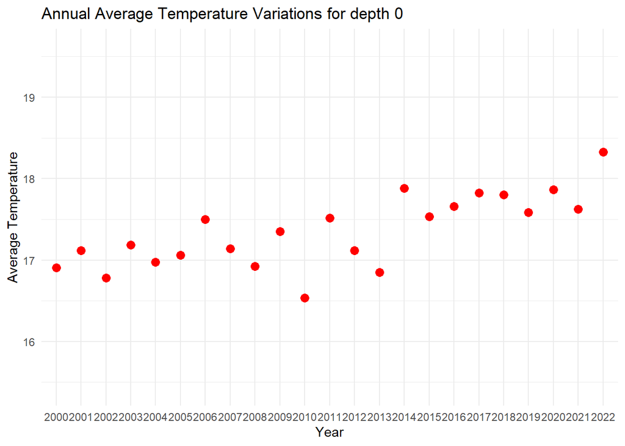

```r
print(plot_0)
```

```r
print(average_temperature_by_year_20)
```

```
## # A tibble: 23 × 2
##    Year       Average_Temperature
##    <labelled>               <dbl>
##  1 2000                      16.4
##  2 2001                      16.6
##  3 2002                      16.3
##  4 2003                      16.3
##  5 2004                      16.3
##  6 2005                      16.3
##  7 2006                      16.7
##  8 2007                      16.6
##  9 2008                      16.3
## 10 2009                      16.8
## # ℹ 13 more rows
```

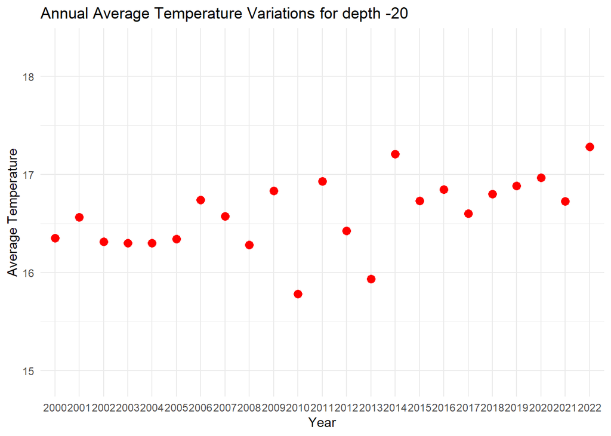

```r
print(plot_20)
```

```r
print(average_temperature_by_year_50)
```

```
## # A tibble: 23 × 2
##    Year       Average_Temperature
##    <labelled>               <dbl>
##  1 2000                      14.8
##  2 2001                      15.2
##  3 2002                      14.8
##  4 2003                      14.7
##  5 2004                      14.6
##  6 2005                      15.0
##  7 2006                      15.0
##  8 2007                      15.3
##  9 2008                      14.6
## 10 2009                      15.0
## # ℹ 13 more rows
```

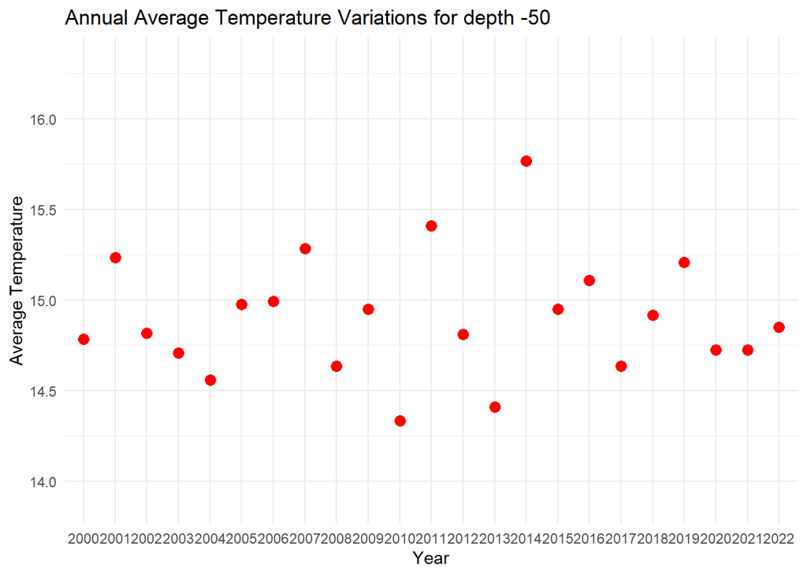

```r
print(plot_50)
```

```r
print(average_temperature_by_year_80)
```

```
## # A tibble: 23 × 2
##    Year       Average_Temperature
##    <labelled>               <dbl>
##  1 2000                      13.6
##  2 2001                      14.0
##  3 2002                      13.8
##  4 2003                      13.9
##  5 2004                      13.7
##  6 2005                      13.7
##  7 2006                      13.8
##  8 2007                      14.1
##  9 2008                      13.6
## 10 2009                      13.9
## # ℹ 13 more rows
```

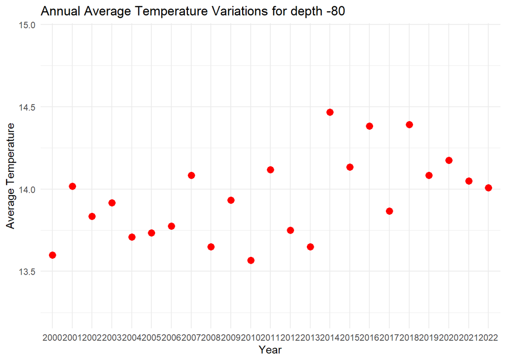

```r
print(plot_80)
```

In this first part we calculate the average temperature per year. Then we create a dot plot of the calculated average temperature per year. Looking at the graph you can see an increasing trend over the years.

```r
calculate_and_print_differences <- function(average_temperature_by_year, depth) {
  differences <- average_temperature_by_year %>%
    group_by(Year) %>%
    summarise(Mean_Temperature = mean(Average_Temperature)) %>%
    mutate(Difference = Mean_Temperature - lag(Mean_Temperature))

  print(differences)

  return(differences)
}

differences_0 <- calculate_and_print_differences(average_temperature_by_year_0, "0")
```

```
## # A tibble: 23 × 3
##    Year       Mean_Temperature Difference
##    <labelled>            <dbl>      <dbl>
##  1 2000                   16.9    NA
##  2 2001                   17.1     0.208
##  3 2002                   16.8    -0.333
##  4 2003                   17.2     0.400
##  5 2004                   17.0    -0.208
##  6 2005                   17.1     0.0833
##  7 2006                   17.5     0.442
##  8 2007                   17.1    -0.358
##  9 2008                   16.9    -0.217
## 10 2009                   17.4     0.425
## # ℹ 13 more rows
```

```r
differences_20 <- calculate_and_print_differences(average_temperature_by_year_20, "-20")
```

```
## # A tibble: 23 × 3
##    Year       Mean_Temperature Difference
##    <labelled>            <dbl>      <dbl>
##  1 2000                   16.4    NA
##  2 2001                   16.6     0.217
##  3 2002                   16.3    -0.25
##  4 2003                   16.3    -0.0167
##  5 2004                   16.3     0
##  6 2005                   16.3     0.0417
##  7 2006                   16.7     0.400
##  8 2007                   16.6    -0.167
##  9 2008                   16.3    -0.292
## 10 2009                   16.8     0.550
## # ℹ 13 more rows
```

```r
differences_50 <- calculate_and_print_differences(average_temperature_by_year_50, "-50")
```

```
## # A tibble: 23 × 3
##    Year       Mean_Temperature Difference
##    <labelled>            <dbl>      <dbl>
##  1 2000                   14.8    NA
##  2 2001                   15.2     0.450
##  3 2002                   14.8    -0.417
##  4 2003                   14.7    -0.108
##  5 2004                   14.6    -0.150
##  6 2005                   15.0     0.417
##  7 2006                   15.0     0.0167
##  8 2007                   15.3     0.292
##  9 2008                   14.6    -0.65
## 10 2009                   15.0     0.317
## # ℹ 13 more rows
```

```r
differences_80 <- calculate_and_print_differences(average_temperature_by_year_80, "-80")
```

```
## # A tibble: 23 × 3
##    Year       Mean_Temperature Difference
##    <labelled>            <dbl>      <dbl>
##  1 2000                   13.6    NA
##  2 2001                   14.0     0.417
##  3 2002                   13.8    -0.183
##  4 2003                   13.9     0.0833
##  5 2004                   13.7    -0.208
##  6 2005                   13.7     0.0250
##  7 2006                   13.8     0.0417
##  8 2007                   14.1     0.308
##  9 2008                   13.6    -0.433
## 10 2009                   13.9     0.283
## # ℹ 13 more rows
```

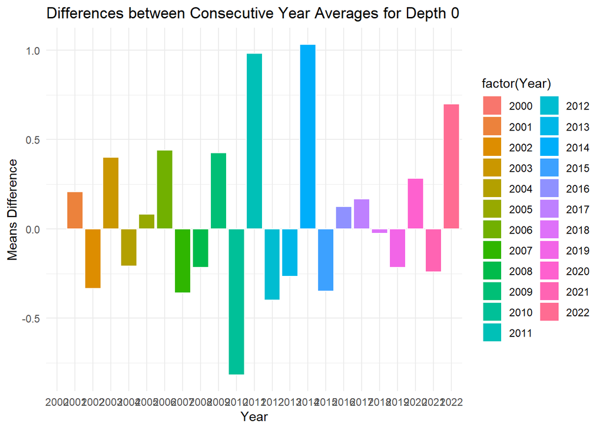

```r
plot_differences <- function(differences, depth) {
  ggplot(differences, aes(x = factor(Year), y = Difference, fill = factor(Year))) +
    geom_bar(stat = "identity", position = "dodge", color = "white") +
    labs(title = sprintf("Differences between Consecutive Year Averages for Depth %s", depth), x = "Year", y = "Means Difference") +
    theme_minimal()
}

plot_differences_0 <- plot_differences(differences_0, "0")
plot_differences_20 <- plot_differences(differences_20, "-20")
plot_differences_50 <- plot_differences(differences_50, "-50")
plot_differences_80 <- plot_differences(differences_80, "-80")

print(plot_differences_0)
```

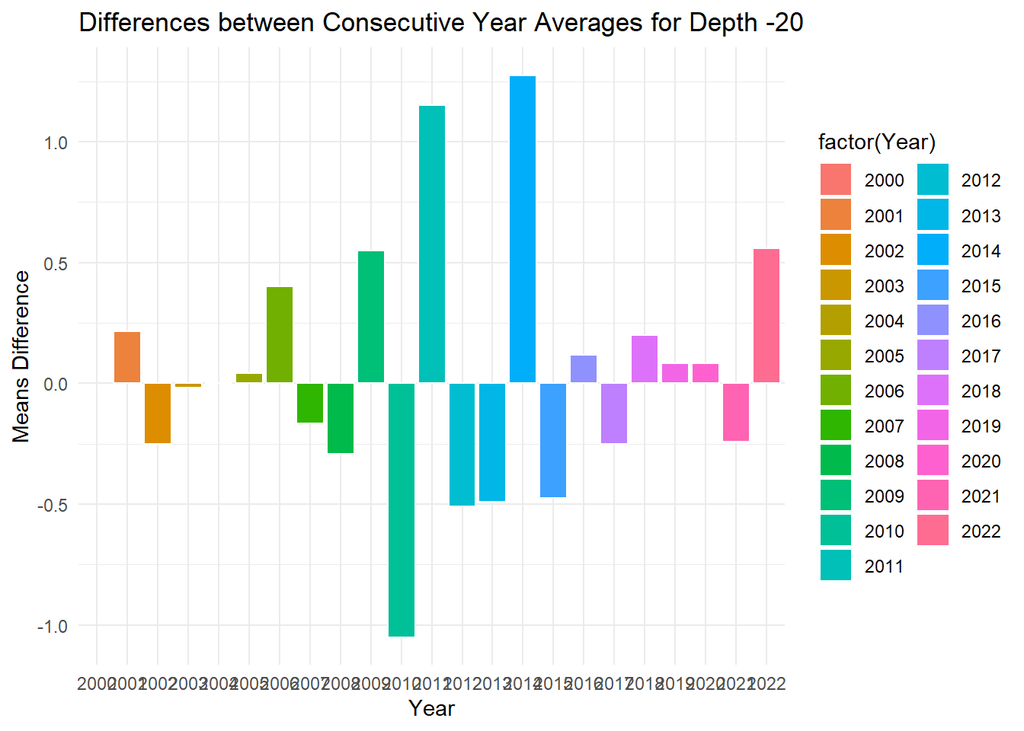

```r
print(plot_differences_20)
```

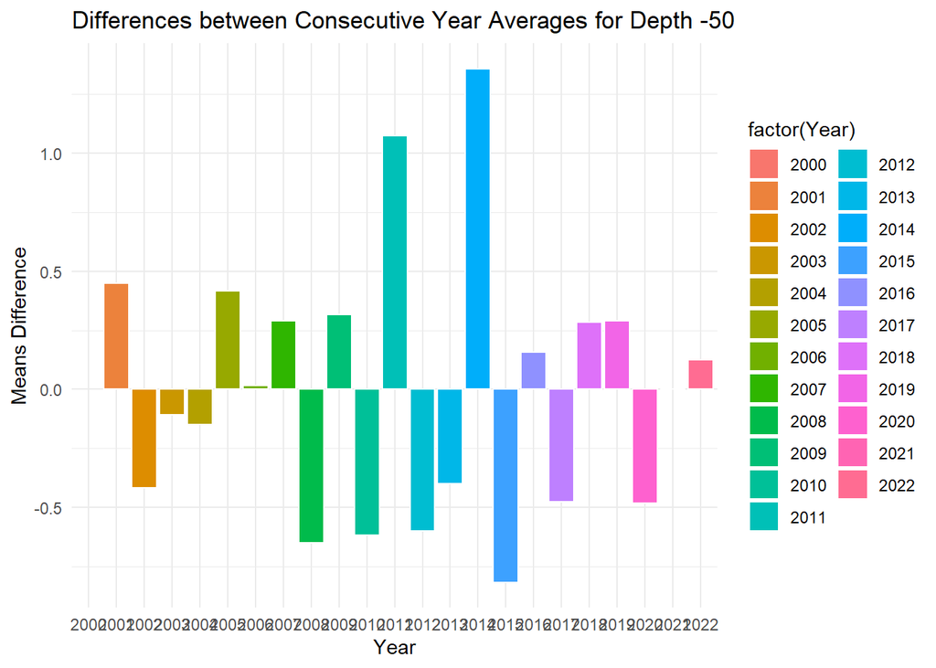

```r
print(plot_differences_50)
```

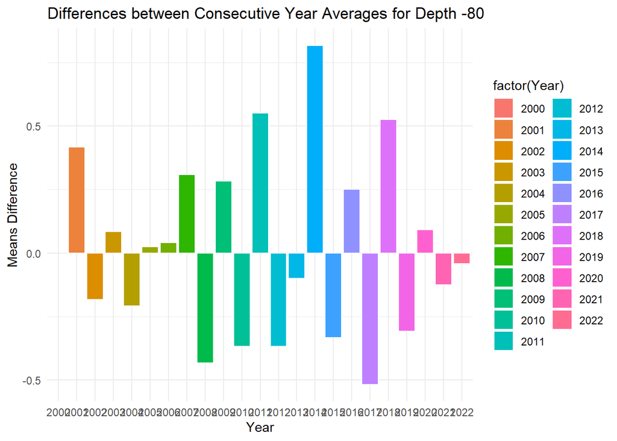

```r
print(plot_differences_80)
```

In this second part we calculate the differences in average temperatures between consecutive years. Generates a data frame with the year, the average temperature and another column with the differences with the previous year, that is why the first value of this third column is always NA. This is why the first value of this third column is always NA, since for the year 2000 we have no previous data to calculate the difference. These graphs plot the differences calculated above, we can see that there is no clear trend. There are negative and positive differences.

```r
año_base <- 2000

library(ggplot2)

calculate_and_plot_variations <- function(df, depth) {
  variaciones_por_año <- df %>%
    mutate(Variacion = Average_Temperature - filter(df, Year == año_base)$Average_Temperature)

  print(variaciones_por_año)

  ggplot(variaciones_por_año, aes(x = factor(Year), y = Variacion, fill = factor(Year))) +
    geom_bar(stat = "identity", position = "dodge", color = "white") +
    labs(title = sprintf("Average Temperature Variations per Year depth %s (vs. 2000)", depth), x = "Year", y = "Average Temperature Variation") +
    theme_minimal()
}

plot_depth_0 <- calculate_and_plot_variations(average_temperature_by_year_0, "0")
```

```
## # A tibble: 23 × 3
##    Year       Average_Temperature Variacion
##    <labelled>               <dbl>     <dbl>
##  1 2000                      16.9    0
##  2 2001                      17.1    0.208
##  3 2002                      16.8   -0.125
##  4 2003                      17.2    0.275
##  5 2004                      17.0    0.0667
##  6 2005                      17.1    0.150
##  7 2006                      17.5    0.592
##  8 2007                      17.1    0.233
##  9 2008                      16.9    0.0167
## 10 2009                      17.4    0.442
## # ℹ 13 more rows
```

```r
plot_depth_20 <- calculate_and_plot_variations(average_temperature_by_year_20, "-20")
```

```
## # A tibble: 23 × 3
##    Year       Average_Temperature Variacion
##    <labelled>               <dbl>     <dbl>
##  1 2000                      16.4   0
##  2 2001                      16.6   0.217
##  3 2002                      16.3  -0.0333
##  4 2003                      16.3  -0.0500
##  5 2004                      16.3  -0.0500
##  6 2005                      16.3  -0.00833
##  7 2006                      16.7   0.392
##  8 2007                      16.6   0.225
##  9 2008                      16.3  -0.0667
## 10 2009                      16.8   0.483
## # ℹ 13 more rows
```

```r
plot_depth_50 <- calculate_and_plot_variations(average_temperature_by_year_50, "-50")
```

```
## # A tibble: 23 × 3
##    Year       Average_Temperature Variacion
##    <labelled>               <dbl>     <dbl>
##  1 2000                      14.8    0
##  2 2001                      15.2    0.450
##  3 2002                      14.8    0.0333
##  4 2003                      14.7   -0.0750
##  5 2004                      14.6   -0.225
##  6 2005                      15.0    0.192
##  7 2006                      15.0    0.208
##  8 2007                      15.3    0.5
##  9 2008                      14.6   -0.150
## 10 2009                      15.0    0.167
## # ℹ 13 more rows
```

```r
plot_depth_80 <- calculate_and_plot_variations(average_temperature_by_year_80, "-80")
```

```
## # A tibble: 23 × 3
##    Year       Average_Temperature Variacion
##    <labelled>               <dbl>     <dbl>
##  1 2000                      13.6    0
##  2 2001                      14.0    0.417
##  3 2002                      13.8    0.233
##  4 2003                      13.9    0.317
##  5 2004                      13.7    0.108
##  6 2005                      13.7    0.133
##  7 2006                      13.8    0.175
##  8 2007                      14.1    0.483
##  9 2008                      13.6    0.0500
## 10 2009                      13.9    0.333
## # ℹ 13 more rows
```

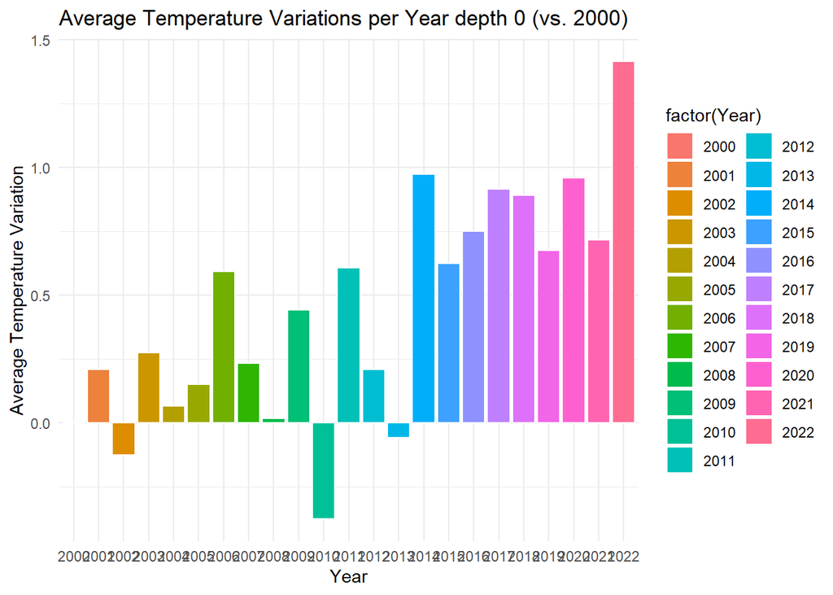

```r
print(plot_depth_0)
```

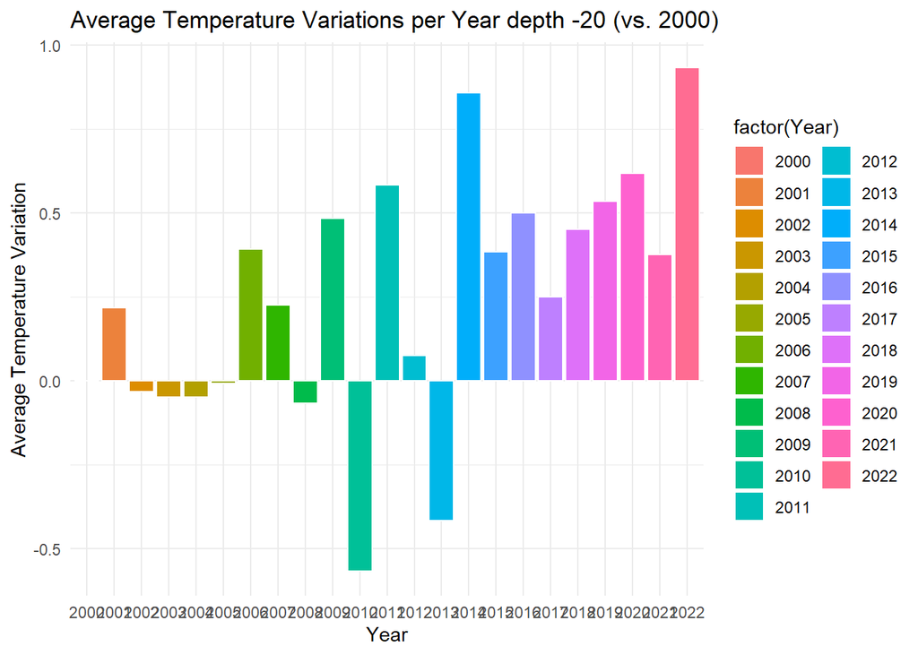

```r
print(plot_depth_20)
```

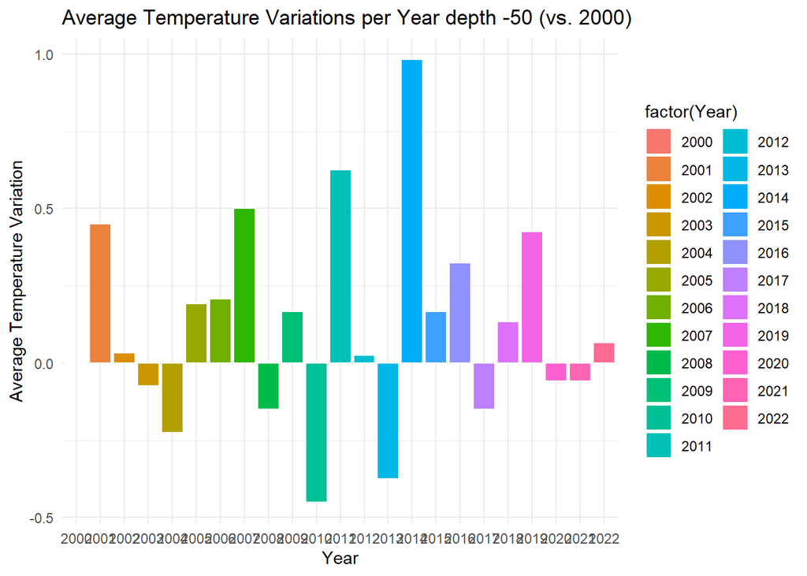

```r
print(plot_depth_50)
```

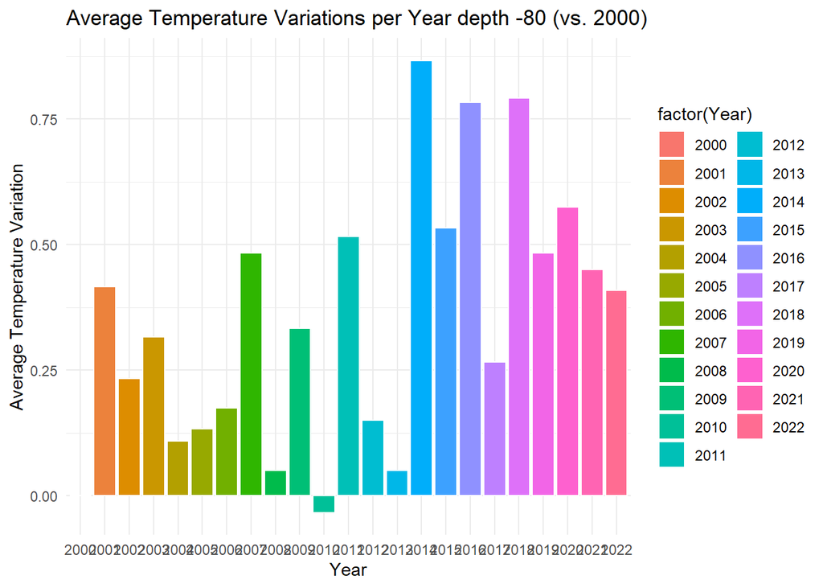

```r
print(plot_depth_80)
```

Section G

Export data frame with the new variables created to a new file sheet, for example in NUEVO.xlsx.

**Answer**

```r
#Exercici 1g

library(dplyr)

resultado_0 <- cbind(statistics_by_year_0,differences_0)
resultado_0 <- resultado_0 %>%
  select(unique(names(.)))%>%
  mutate(Nueva_Columna = "Depth_0")
nom_resultado_0 <- c("Year", "Mean_Temperature", "Median_Temperature", "SD_Temperature", "IQR_Temperature", "Min_Temperature", "Max_Temperature", "Q10_Temperature", "Q90_Temperature", "Year",
                     "Mean_Temperature", "Difference", "Nueva_Col")
colnames(resultado_0) <- nom_resultado_0

resultado_20 <- cbind(statistics_by_year_20,differences_20)
resultado_20 <- resultado_20 %>%
  select(unique(names(.)))%>%
  mutate(Nueva_Columna = "Depth_-20")
colnames(resultado_20) <- nom_resultado_0

resultado_50 <- cbind(statistics_by_year_50,differences_50)
resultado_50 <- resultado_50 %>%
  select(unique(names(.)))%>%
  mutate(Nueva_Columna = "Depth_-50")
colnames(resultado_50) <- nom_resultado_0

resultado_80 <- cbind(statistics_by_year_80,differences_80)
resultado_80 <- resultado_80 %>%
  select(unique(names(.)))%>%
  mutate(Nueva_Columna = "Depth_-80")
colnames(resultado_80) <- nom_resultado_0

resultado <- bind_rows(resultado_0, resultado_20, resultado_50, resultado_80)
head(resultado)
```

```
##   Year...1 Mean_Temperature...2 Median_Temperature SD_Temperature
## 1     2000             16.90833              16.85       3.647778
## 2     2001             17.11667              16.50       3.757377
## 3     2002             16.78333              16.00       3.326979
## 4     2003             17.18333              16.15       4.493800
## 5     2004             16.97500              15.75       4.022691
## 6     2005             17.05833              16.70       3.838906
##   IQR_Temperature Min_Temperature Max_Temperature Q10_Temperature
## 1           6.700            12.7            22.0           12.81
## 2           6.150            12.5            23.2           13.22
## 3           6.075            12.9            21.3           13.31
## 4           7.650            12.0            24.7           12.32
## 5           7.050            12.2            23.0           12.64
## 6           6.600            12.4            23.1           12.86
##   Q90_Temperature Year...10 Mean_Temperature...11  Difference Nueva_Col
## 1           21.82      2000              16.90833          NA   Depth_0
## 2           21.80      2001              17.11667  0.20833333   Depth_0
## 3           20.99      2002              16.78333 -0.33333333   Depth_0
## 4           23.12      2003              17.18333  0.40000000   Depth_0
## 5           22.00      2004              16.97500 -0.20833333   Depth_0
## 6           22.16      2005              17.05833  0.08333333   Depth_0
```

```r
library(openxlsx)
write.xlsx(resultado, file = "NUEVO.xlsx", sheetName = "Sheet1", colNames = TRUE)
```

In this exercise, we gather the data calculated in the previous exercises and put them together in a single data frame so that we can later export it to excel.

Exercise 2

Section A

Make two or more graphs with the data from Exercise 1 using functions from two of the following packages: gplots, plotrix, vcd. For (at least) one of the two graphs you should use the study group variable (depth or year) and for the other one a couple of the numerical variables. Present the syntax and interpret both graphs.

**Answer**

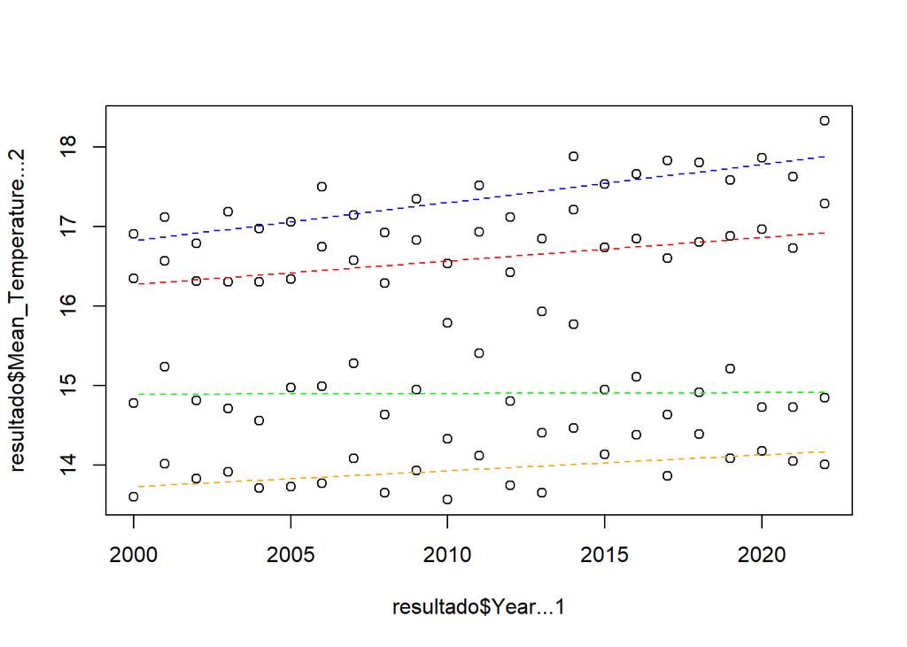

```r
#Exercici 2

library(plotrix)
library(gplots)

#using a function of plotrix: ablineclip

lmfit_0<-lm(resultado$Mean_Temperature...2[1:23]~resultado$Year...1[1:23])
lmfit_20<-lm(resultado$Mean_Temperature...2[24:46]~resultado$Year...1[24:46])
lmfit_50<-lm(resultado$Mean_Temperature...2[47:69]~resultado$Year...1[47:69])
lmfit_80<-lm(resultado$Mean_Temperature...2[70:92]~resultado$Year...1[70:92])

plot(resultado$Year...1,resultado$Mean_Temperature...2)
ablineclip(lmfit_0, x1 = 2000, x2 = 2022, lty = 8,col="blue")
ablineclip(lmfit_20, x1 = 2000, x2 = 2022, lty = 8, col="red")
ablineclip(lmfit_50, x1 = 2000, x2 = 2022, lty = 8, col="green")
ablineclip(lmfit_80, x1 = 2000, x2 = 2022, lty = 8, col= "orange")
```

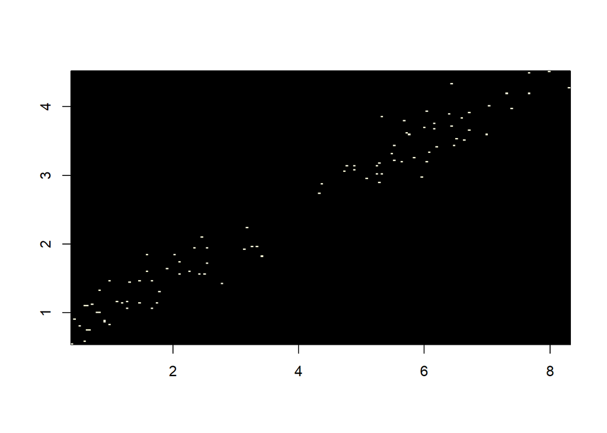

```
##
## ----------------------------
## 2-D Histogram Object
## ----------------------------
##
## Call: hist2d(x = resultado$IQR_Temperature, y = resultado$SD_Temperature)
##
## Number of data points:  92
## Number of grid bins:  200 x 200
## X range: ( 0.375 , 8.325 )
## Y range: ( 0.5382351 , 4.520886 )
```

```r
#Exercici 2

#using a function of gplots: hist2d
hist2d(resultado$IQR_Temperature,resultado$SD_Temperature)
```

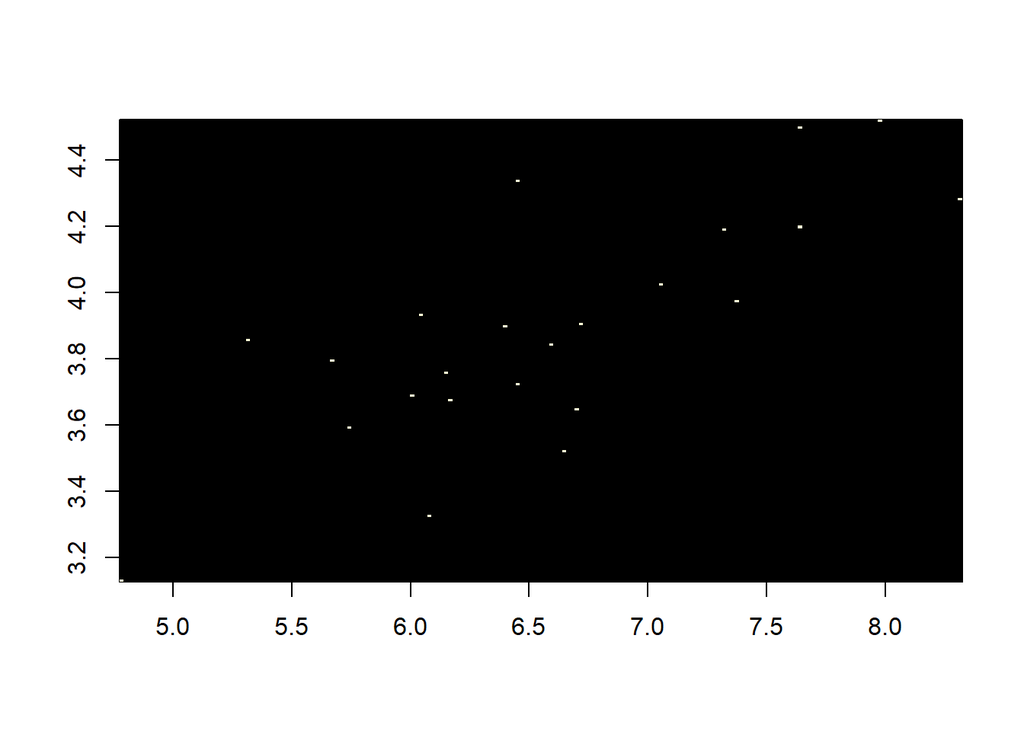

```
##
## ----------------------------
## 2-D Histogram Object
## ----------------------------
##
## Call: hist2d(x = resultado$IQR_Temperature[1:23], y = resultado$SD_Temperature[1:23])
##
## Number of data points:  23
## Number of grid bins:  200 x 200
## X range: ( 4.775 , 8.325 )
## Y range: ( 3.127723 , 4.520886 )
```

```r
hist2d(resultado$IQR_Temperature[1:23],resultado$SD_Temperature[1:23])
```

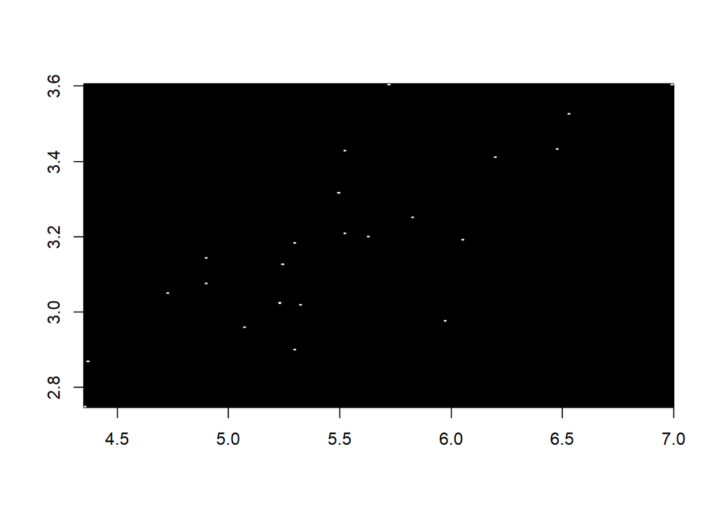

```
##
## ----------------------------
## 2-D Histogram Object
## ----------------------------
##
## Call: hist2d(x = resultado$IQR_Temperature[24:46], y = resultado$SD_Temperature[24:46])
##
## Number of data points:  23
## Number of grid bins:  200 x 200
## X range: ( 4.35 , 7 )
## Y range: ( 2.746278 , 3.606423 )
```

```r
hist2d(resultado$IQR_Temperature[24:46],resultado$SD_Temperature[24:46])
```

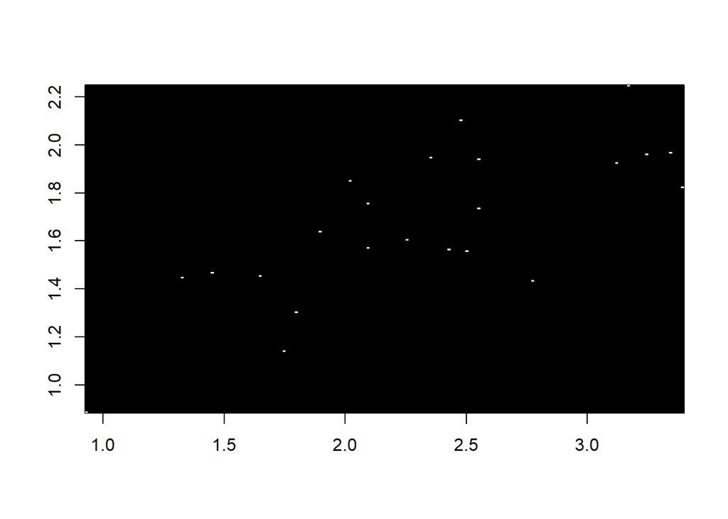

```
##
## ----------------------------
## 2-D Histogram Object
## ----------------------------
##
## Call: hist2d(x = resultado$IQR_Temperature[47:69], y = resultado$SD_Temperature[47:69])
##
## Number of data points:  23
## Number of grid bins:  200 x 200
## X range: ( 0.925 , 3.4 )
## Y range: ( 0.8833047 , 2.24963 )
```

```r
hist2d(resultado$IQR_Temperature[47:69],resultado$SD_Temperature[47:69])
```

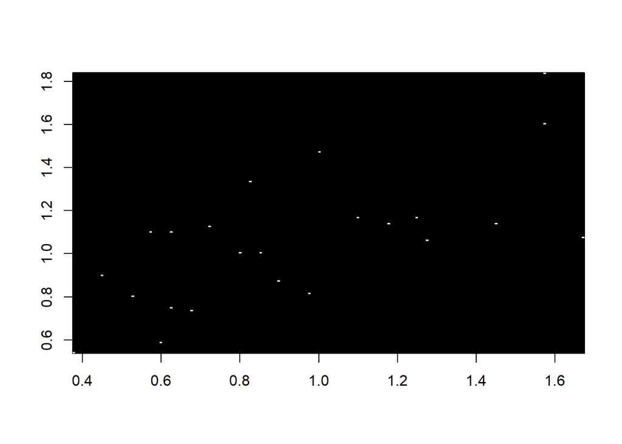

```
##
## ----------------------------
## 2-D Histogram Object
## ----------------------------
##
## Call: hist2d(x = resultado$IQR_Temperature[70:92], y = resultado$SD_Temperature[70:92])
##
## Number of data points:  23
## Number of grid bins:  200 x 200
## X range: ( 0.375 , 1.675 )
## Y range: ( 0.5382351 , 1.840187 )
```

```r
hist2d(resultado$IQR_Temperature[70:92],resultado$SD_Temperature[70:92])
```

With this second graph, we plot the relationship between the IQR and the SD, both of temperature. We can see a clear positive relationship between these two numerical variables: the higher the interquartile range, the higher the variance, which is completely normal. However, we can observe 2 groups of points in the graph. The points closest to the point (0,0) belong to the temperature data of the observations. Depth -50 and Depth -80, on the other hand, the furthest ones are the Depth -20 and Depth 0 groups. At shallower depths, the temperature variances are higher, as is the interquartile range, while in deeper water, the opposite is true. To demonstrate this, we then create the 4 plots of the 4 different depths. Looking at the axes of each graph, you can see the difference in values.

Exercise 3

Section A

Calculate the temperature between one month and the following month (eg January and February) for each year and depth, offer a graph per year and the average of all years studied. You should be able to indicate what years or depths it should represent.

**Answer**

```r
#Exercici 3a
process_and_graph_sea_temp <- function(sea.deep, year = NULL, depth = NULL, type = NULL) {
  # Load necessary libraries
  library(dplyr)
  library(lubridate)
  library(ggplot2)

  # Duplicate the original dataframe
  sea.deep_copy <- sea.deep

  # Data preprocessing steps
  sea.deep_copy <- sea.deep_copy %>%
    mutate(Temperature = as.numeric(gsub(",", ".", Temperature))) %>%
    mutate(Month = gsub("-[0-9]{4}", "", Month))

  # Filter and sort the data
  sea.deep_filtered <- sea.deep_copy %>%
    filter(!grepl("Mitjana", Month)) %>%
    mutate(Year_Month = make_date(Year, match(Month, month.abb), 1)) %>%
    arrange(Year_Month, Depth, Type)

  # Calculate the temperature difference
  sea.deep_diff <- sea.deep_filtered %>%
    group_by(Depth, Type) %>%
    mutate(Temp_Diff = c(NA, diff(Temperature))) %>%
    ungroup() %>%
    select(-Year_Month)

  # Define month order
  month_order <- c("Gener", "Febrer", "Març", "Abril", "Maig", "Juny",
                   "Juliol", "Agost", "Setembre", "Octubre", "Novembre", "Desembre")

  # Filter out rows with missing or incorrect Month values
  sea.deep_diff <- sea.deep_diff %>%
    filter(Month %in% month_order)

  # Create graph based on the input parameters
  if (!is.null(year)) {
    # Specific year graph
    filtered_data <- sea.deep_diff %>%
      filter(Year == year, Depth == depth, Type == type) %>%
      mutate(Month = factor(Month, levels = month_order)) %>%
      drop_na(Temp_Diff)

    graph <- ggplot(filtered_data, aes(x = Month, y = Temp_Diff, fill = Temp_Diff)) +
      geom_col() +
      scale_fill_gradient(low = "green", high = "red") +
      theme_minimal() +
      theme(axis.text.x = element_text(angle = 45, hjust = 1),
            legend.position = "none") +
      ggtitle(paste("Temperature Difference for", depth, "in", year, "-", type)) +
      xlab("Month") +
      ylab("Temperature Difference (°C)")
  } else {
    # Average temperature difference graph
    avg_temp_diff <- sea.deep_diff %>%
      group_by(Month) %>%
      summarise(Avg_Temp_Diff = mean(Temp_Diff, na.rm = TRUE)) %>%
      mutate(Month = factor(Month, levels = month_order))

    graph <- ggplot(avg_temp_diff, aes(x = Month, y = Avg_Temp_Diff, fill = Avg_Temp_Diff)) +
      geom_col() +
      scale_fill_gradient2(low = "green", high = "red", mid = "yellow", midpoint = 0) +
      theme_minimal() +
      theme(axis.text.x = element_text(angle = 45, hjust = 1),
            legend.position = "none") +
      ggtitle("Average Temperature Difference") +
      xlab("Month") +
      ylab("Average Temperature Difference (°C)")
  }

  return(graph)
}
```

The function begins by transforming the Temperature column from a text format to numeric. Then it extracts only the month names from the Month column, omitting rows labeled ‘Mitjana Anual’ which do not fit the intended analysis.

A critical part of the script involves calculating the temperature differences between consecutive months. For this, the function creates a new column Year_Month for easier sorting and organizes the data by this column, Depth, and Type. It computes the temperature change between each month, assigning NA to the first entry of each group (like Gener 2000) because there’s no preceding month for comparison (as in the case of a missing Desembre 1999).

The function then proceeds to create graphs based on specified parameters. When a specific year, depth, and type are selected, the function filters the data accordingly and uses ggplot2 to create a visualization. This graph shows the temperature changes for each month of the chosen year. If no year is specified, the function produces a graph displaying the average temperature change across all years/depths. The visualizations use a color gradient to represent temperature changes, making it easy to identify and understand trends in the data.

This function effectively handles data processing and visualization, providing a flexible tool for analyzing sea temperature changes over time based on different parameters. The use of color gradients in the graphs enhances the interpretability of the temperature changes.

**Example 1:Graph for year 2001, depth “Depth_-20”, type “Current Year”**

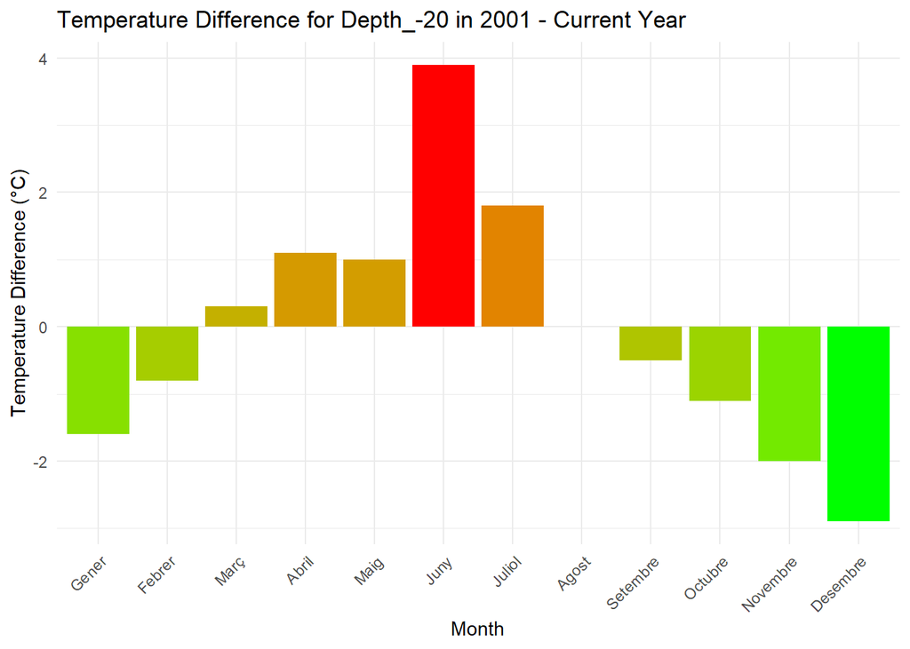

```r
# Example: Graph for year 2001, depth "Depth_-20", type "Current Year"
graph_2001_20m_Current <- process_and_graph_sea_temp(sea.deep, 2001, "Depth_-20", "Current Year")
print(graph_2001_20m_Current)
```

**Example 2:Average temperature difference for all years**

```r
# Example: Average temperature difference for all years
graph_all_avg <- process_and_graph_sea_temp(sea.deep)
print(graph_all_avg)
```

[output not shown]

```r
# Example: Average temperature difference for all years of type "Current Year"
graph_type_avg <- process_and_graph_sea_temp(sea.deep, type = "Current Year")
print(graph_type_avg)
```

[output not shown]

```r
# Example: Average temperature difference for all years at depth "Depth_0" and type "Current Year"
graph_depth_type_avg <- process_and_graph_sea_temp(sea.deep, depth = "Depth_0", type = "Current Year")
print(graph_depth_type_avg)
```

[output not shown]

Section B

Calculate the difference between the temperature of each month and the same month of the previous 30 years (example: January 2000 and January period 1974-1999), offer a graph for each year and the average of All years studied. You should be able to indicate what year or depths it should represent.

**Answer**

```r
#Exercise 3b

firstFinalResult <- NULL
plot_temperature_diff <- function(sea.deep, year = NULL, depth = NULL) {
  # Copy the original sea.deep dataframe
  sea.deep_copy2 <- sea.deep

  # Convert Temperature to numeric
  sea.deep_copy2$Temperature <- as.numeric(gsub(",", ".", sea.deep_copy2$Temperature))

  # Process the Month column for current_data
  current_data <- sea.deep_copy2 %>% filter(Type == "Current Year") %>% select(-Type)
  current_data$Month <- gsub("-[0-9]{4}", "", current_data$Month)

  # Process the Month column for historical_data
  historical_data <- sea.deep_copy2 %>% filter(Type == "Historical") %>% select(-Type)
  historical_data$Month <- gsub("-Període [0-9]{4}-[0-9]{4}", "", historical_data$Month)

  # Define the order of months and 'Mitjana anual'
  month_order <- c("Gener", "Febrer", "Març", "Abril", "Maig", "Juny",
                   "Juliol", "Agost", "Setembre", "Octubre", "Novembre",
                   "Desembre", "Mitjana anual")

  # Initialize an empty list to store results
  results_list <- list()

  # Iterate over each year and depth
  for (yr in unique(current_data$Year)) {
    for (dpth in unique(current_data$Depth)) {
      # Filter current and historical data for the year and depth
      current_filtered <- filter(current_data, Year == yr, Depth == dpth)
      historical_filtered <- filter(historical_data, Year == yr, Depth == dpth)

      # Merge the filtered data on Month and Depth
      merged_data <- merge(current_filtered, historical_filtered,
                           by = c("Month", "Depth"),
                           suffixes = c("_Current", "_Historical"))

      # Arrange the merged data by Month
      merged_data <- merged_data %>%
        mutate(Month = factor(Month, levels = month_order)) %>%
        arrange(Month)

      # Calculate temperature difference
      merged_data$Temp_Diff_30yr <- merged_data$Temperature_Current - merged_data$Temperature_Historical

      # Add the merged data to the results list
      results_list[[paste(yr, dpth, sep = "_")]] <- merged_data
    }
  }

  # Combine all results into a single data frame
  final_result <- do.call(rbind, results_list)

  # Some additional transformations
  final_result <- final_result[-6]
  final_result <- final_result[c(1:2, 4, 3, 5:ncol(final_result))]
  if (is.null(firstFinalResult)) {
          firstFinalResult <<- final_result
          message("First dataset result saved.")
      }
  # Plotting
  if (!is.null(year) && !is.null(depth)) {
    data <- subset(final_result, Year_Current == year & Depth == depth)
  } else if (!is.null(year)) {
    # Specific year, all depths
    data <- subset(final_result, Year_Current == year)
    data <- aggregate(Temp_Diff_30yr ~ Month, data = data, FUN = mean, na.rm = TRUE)
  } else if (!is.null(depth)) {
    # Specific depth, all years
    data <- subset(final_result, Depth == depth)
    data <- aggregate(Temp_Diff_30yr ~ Month, data = data, FUN = mean, na.rm = TRUE)
  } else {
    # Average across all years and depths
    data <- aggregate(Temp_Diff_30yr ~ Month, data = final_result, FUN = mean, na.rm = TRUE)
  }

  ggplot(data, aes(x = Month, y = Temp_Diff_30yr, fill = Temp_Diff_30yr)) +
    geom_bar(stat = "identity") +
    scale_fill_gradient2(low = "green", high = "red", mid = "yellow", midpoint = 0) +
    labs(title = "Temperature Differences", x = "Month", y = "Temperature Difference (°C)") +
    theme_minimal() +
    theme(legend.position = "none")
}
```

The function begins by creating a copy of the original sea.deep dataset, named sea.deep_copy2. The Temperature column in this copied dataset is then converted from text to numeric format, facilitating numerical analysis.

The script processes the Month column separately for two subsets of the data: current_data (representing the current year’s data) and historical_data (representing historical data spanning 30 years). It extracts just the month names in both subsets for consistent comparison.

The function sets the correct order of months, including ‘Mitjana anual’, and initializes an empty list, results_list, to store the results of the analysis.

In the core analytical part of the script, it iterates over each year and depth. For each combination, it filters the current and historical data, then merges them based on the month and depth. The merged data is used to calculate the temperature difference between the current year and the historical average for the same month.

After completing all calculations, the results are combined into a single dataframe, final_result, with additional transformations for better clarity and organization.

After that, the function proceeds to create graphs that visually represent these temperature differences. It offers flexibility in generating graphs for specific years, depths, or an average across all years and depths. The graphs are created using ggplot2 and employ a color gradient to visually indicate the magnitude of temperature differences. This visualization aids in easy interpretation of the data, highlighting significant trends and anomalies in sea temperature changes over time.

**Example 1:Specific year and depth**

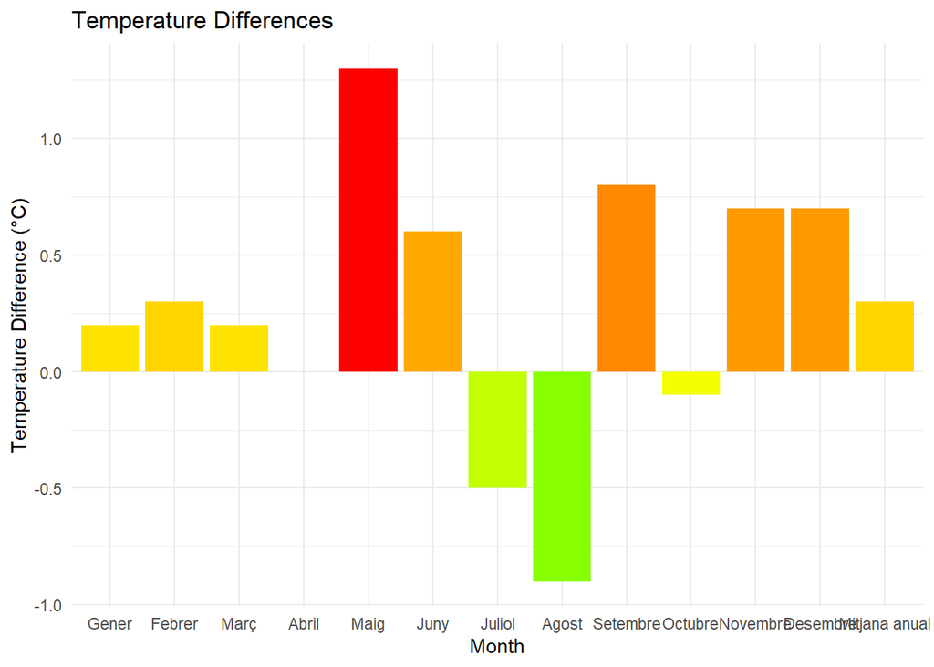

```r
plot_temperature_diff(sea.deep, year=2000, depth = "Depth_0") # Specific year and depth
```

**Example 2:Specific year, all depths**

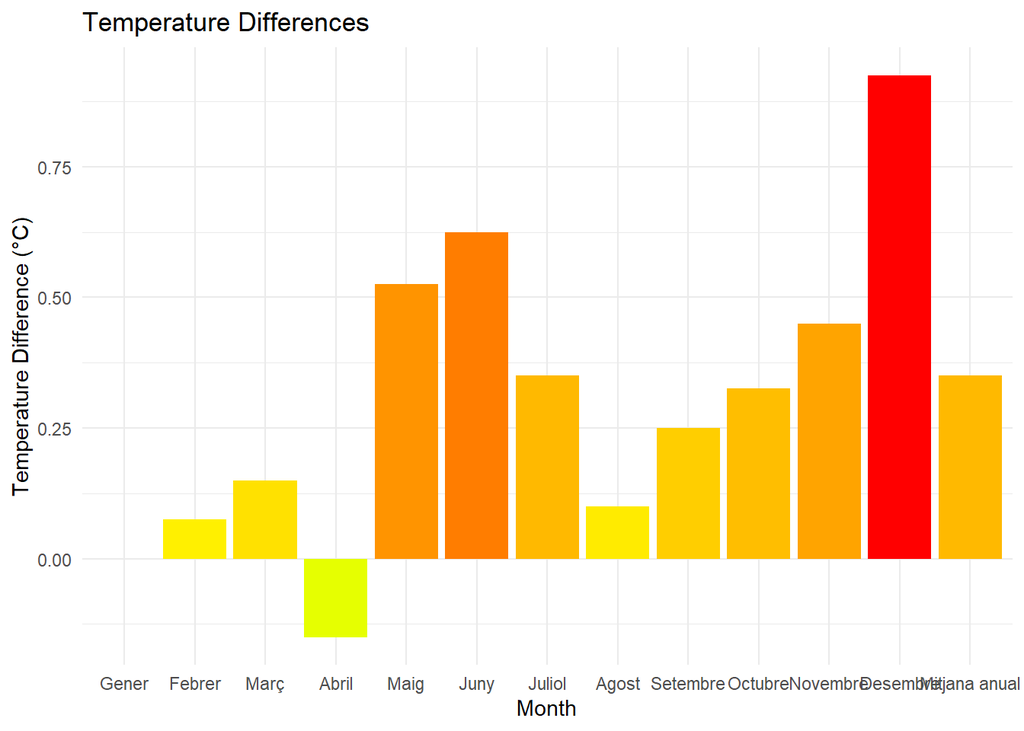

```r
plot_temperature_diff(sea.deep, year = 2000)# Specific year, all depths
```

**Example 3: Specific depth, all years**

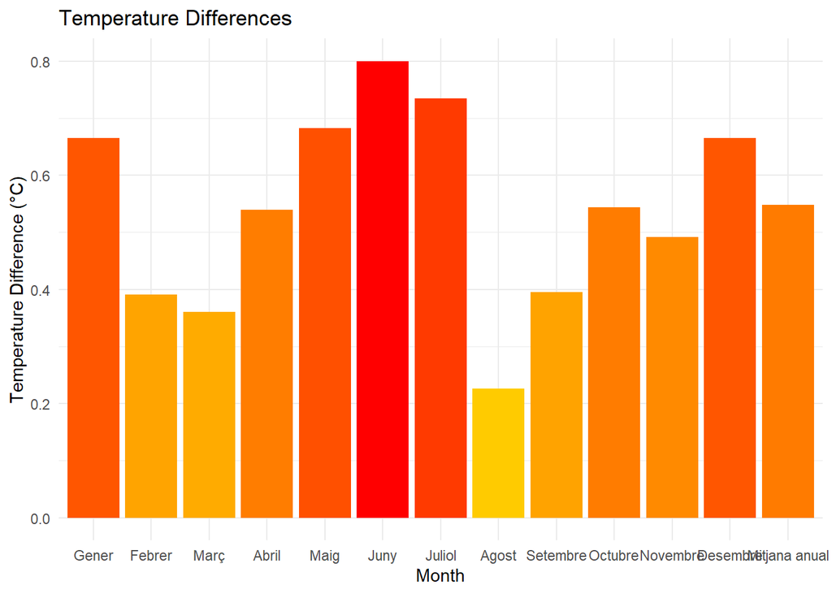

```r
plot_temperature_diff(sea.deep, depth = "Depth_0") # Specific depth, all years
```

**Example 4: Average across all years and depths**

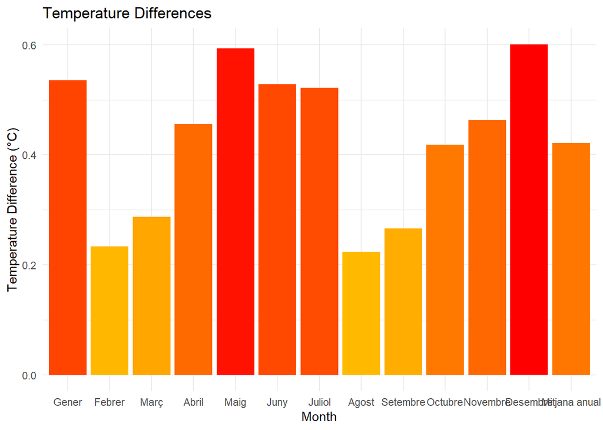

```r
plot_temperature_diff(sea.deep) # Average across all years and depths
```

Section C

Verify the operation of the function with the data frame sea.deep and ensure that everything is correct (optionally you can invent a data frame to verify it, with simulated temperatures using a normal truncated distribution of temperatures and with the same depths).

**Answer**

Assuming you are referring to the functions process_and_graph_sea_temp() and plot_temperature_diff()) presented in section 3A and 3B respectively:

**3A: process_and_graph_sea_temp() function**

```r
#Exercise 3c
simulate_sea_temperature_data <- function(n_years = 2, start_year = 2000, temp_range = c(10, 25)) {
  # Load necessary libraries
  library(truncnorm)
  library(dplyr)

  # Define depths and months
  depths <- c("Depth_0", "Depth_-20", "Depth_-50", "Depth_-80")
  months <- c("Gener", "Febrer", "Març", "Abril", "Maig", "Juny",
              "Juliol", "Agost", "Setembre", "Octubre", "Novembre", "Desembre")

  # Function to simulate data for a year and depth
  simulate_year_data <- function(year, depth) {
    data.frame(
      Month = months,
      Depth = depth,
      Temperature = round(rtruncnorm(length(months), a = temp_range[1],
                                     b = temp_range[2], mean = mean(temp_range),
                                     sd = (temp_range[2] - temp_range[1]) / 4), 1),
      Year = year,
      Type = "Current Year" # Assuming all data is of type "Current Year"
    )
  }

  # Simulate the data
  simulated_data <- do.call(rbind, lapply(start_year:(start_year + n_years - 1),
                                          function(yr) do.call(rbind, lapply(depths,
                                                                             simulate_year_data,
                                                                             year = yr))))

  # Convert Temperature to numeric
  simulated_data$Temperature <- as.numeric(simulated_data$Temperature)

  return(simulated_data)
}


simsea.deep3a <- simulate_sea_temperature_data()
```

The function starts by simulating parameters the years (n_years), the starting year (start_year), and a specified temperature range (temp_range), which defaults to 10 to 25 degrees Celsius.

Depth levels and months of the year are predefined in the function. Depths are specified at various levels, and a range of months (from ‘Gener’ to ‘Desembre’) is listed. These define the dimensions along which the temperature data will be simulated.

A key component of the function is simulate_year_data, an inner function designed to generate temperature data for a given year and depth. It uses the rtruncnorm function to create temperature values that follow a truncated normal distribution within the specified range. The mean of this distribution is set as the midpoint of the temp_range, and the standard deviation (SD) is a measure of variability around this mean within the range.

The simulation process iterates over each year and depth. For each combination, simulate_year_data is called to generate temperature data, resulting in a comprehensive dataset (simulated_data) that mimics real-world temperature variations. This dataset serves as a stand-in for actual sea temperature data, enabling the testing of functions in a controlled environment.

After the simulation, the function ensures that the Temperature column in simulated_data is in numeric format, enhancing its compatibility with subsequent processing and analysis.

The function, simulate_sea_temperature_data, effectively creates a realistic dataset that can be used to test and demonstrate other functions, such as process_and_graph_sea_temp, under simulated conditions. This allows for the evaluation of these functions without the need for real-world data, facilitating development and testing in a controlled and predictable setting. Four examples are provided using the process_and_graph_sea_temp() function showcased in 3A with the new simulated dataset:

**Example 1:Graph for year 2001, depth “Depth_-20”, type “Current Year”**

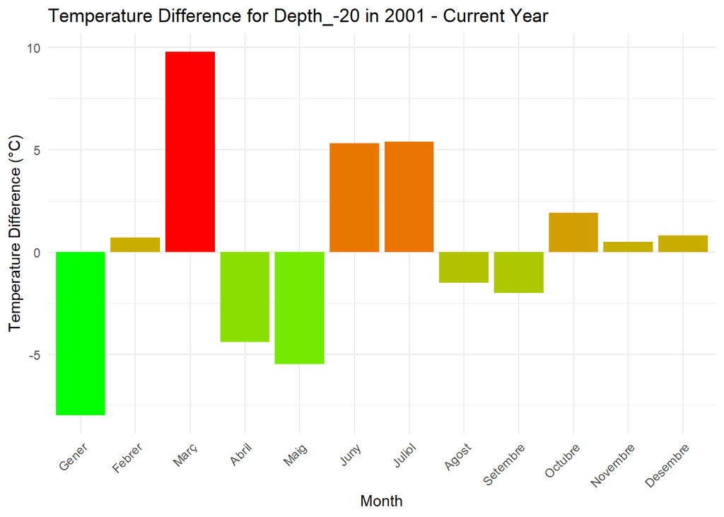

```r
# Example: Graph for year 2001, depth "Depth_-20", type "Current Year"
graph_2001_20m_Current <- process_and_graph_sea_temp(simsea.deep3a, 2001, "Depth_-20", "Current Year")
print(graph_2001_20m_Current)
```

**Example 2:Average temperature difference for all years**

```r
# Example: Average temperature difference for all years
graph_all_avg <- process_and_graph_sea_temp(simsea.deep3a)
print(graph_all_avg)
```

[output not shown]

```r
# Example: Average temperature difference for all years of type "Current Year"
graph_type_avg <- process_and_graph_sea_temp(simsea.deep3a, type = "Current Year")
print(graph_type_avg)
```

[output not shown]

```r
# Example: Average temperature difference for all years at depth "Depth_0" and type "Current Year"
graph_depth_type_avg <- process_and_graph_sea_temp(simsea.deep3a, depth = "Depth_0", type = "Current Year")
print(graph_depth_type_avg)
```

[output not shown]

**3B: plot_temperature_diff() function**

```r
simulate_sea_temperature_data_3b <- function(n_years = 2, start_year = 2000, temp_range = c(10, 25)) {
  # Load necessary libraries
  library(truncnorm)
  library(dplyr)

  # Set seed for reproducibility
  set.seed(111)

  # Define depths and months
  depths <- c("Depth_0", "Depth_-20", "Depth_-50", "Depth_-80")
  months <- c("Gener", "Febrer", "Març", "Abril", "Maig", "Juny",
              "Juliol", "Agost", "Setembre", "Octubre", "Novembre", "Desembre", "Mitjana anual")

  # Function to simulate a year of data for a given depth
  simulate_year_data <- function(year, depth) {
    data.frame(
      Month = rep(months, each = 2),
      Depth = depth,
      Temperature = round(rtruncnorm(length(months) * 2, a = temp_range[1],
                                     b = temp_range[2], mean = mean(temp_range),
                                     sd = (temp_range[2] - temp_range[1]) / 4), 1),
      Year = year,
      Type = rep(c("Current Year", "Historical"), length(months))
    )
  }

  # Simulate data for each year and depth
  simulated_data <- do.call(rbind,
                            lapply(start_year:(start_year + n_years - 1),
                                   function(yr) do.call(rbind,
                                                        lapply(depths,
                                                               simulate_year_data,
                                                               year = yr))))

  # Convert temperatures to character with commas
  simulated_data$Temperature <- gsub("\\.", ",", as.character(simulated_data$Temperature))

  return(simulated_data)
}


simsea.deep3b <- simulate_sea_temperature_data_3b()
```

The simulate_sea_temperature_data function is designed to generate simulated sea temperature data based on specified parameters. The simulation parameters include the number of years (n_years), the starting year (start_year), and a specified temperature range (temp_range), which defaults to 10 to 25 degrees Celsius.

Depth levels and months of the year are predefined in the function. Depths are specified at various levels, and a range of months (from ‘Gener’ to ‘Desembre’) is listed. These define the dimensions along which the temperature data will be simulated.

Simulate_year_data, an inner function designed to generate temperature data for a given year and depth. It uses the rtruncnorm function to create temperature values that follow a truncated normal distribution within the specified range. The mean of this distribution is set as the midpoint of the temp_range, and the standard deviation (SD) is a measure of variability around this mean within the range.

The simulation process iterates over each year and depth. For each combination, simulate_year_data is called to generate temperature data, resulting in a comprehensive dataset (simulated_data) that mimics real-world temperature variations. This dataset serves as a stand-in for actual sea temperature data, enabling the testing of functions in a controlled environment.

The function, simulate_sea_temperature_data, effectively creates a realistic dataset that can be used to test and demonstrate other functions, such as process_and_graph_sea_temp, under simulated conditions. This allows for the evaluation of these functions without the need for real-world data, facilitating development and testing in a controlled and predictable setting.

The plot_temperature_diff function is then demonstrated through four examples:

**Example 1:Specific year and depth**

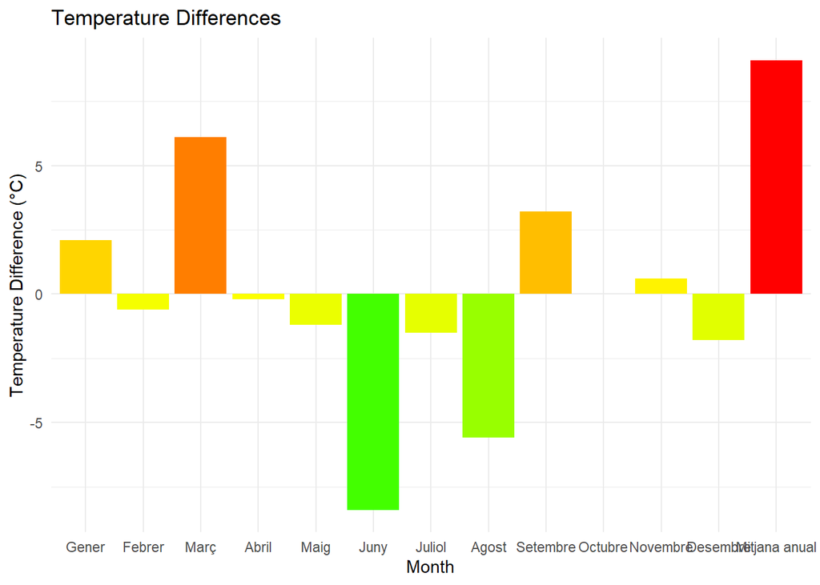

```r
plot_temperature_diff(simsea.deep3b, year=2000, depth ="Depth_0") # Specific year and depth
```

**Example 2:Specific year, all depths**

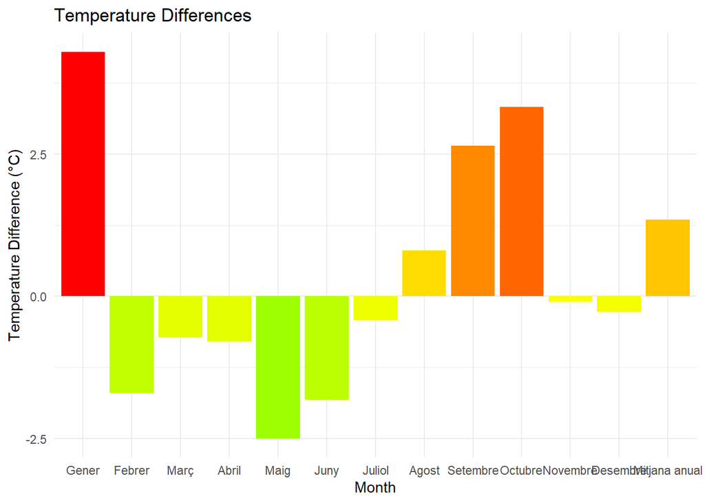

```r
plot_temperature_diff(simsea.deep3b, year=2000) # Specific year, all depths
```

**Example 3: Specific depth, all years**

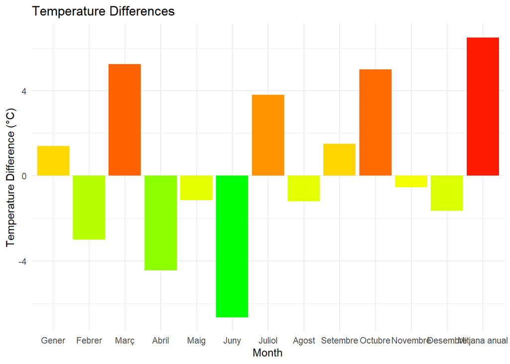

```r
plot_temperature_diff(simsea.deep3b, depth = "Depth_0") # Specific depth, all years
```

**Example 4: Average across all years and depths**

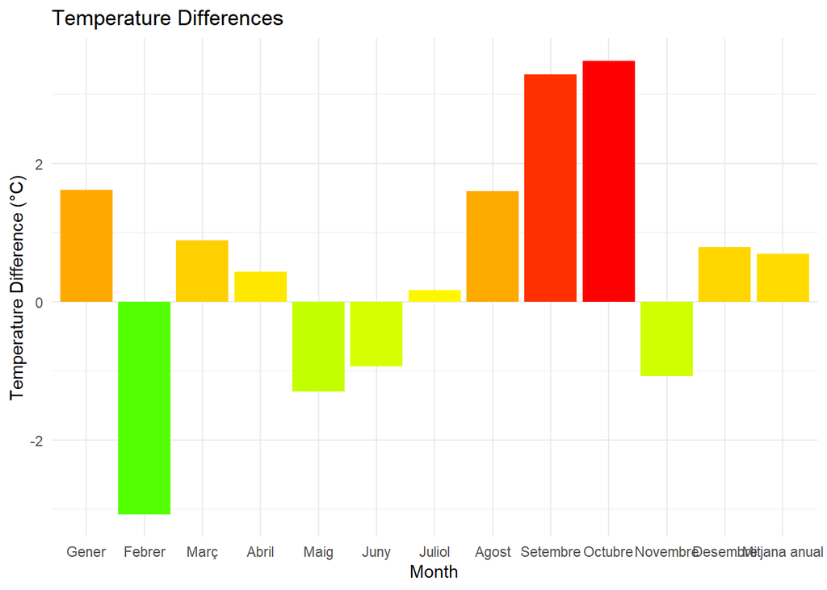

```r
plot_temperature_diff(simsea.deep3b) # Average across all years and depths
```

**Note: There is no pattern in the temperatures of any of the simulated datasets, which is in line with what we would expect from a normal (truncated or not) distribution. The values are randomly distributed (within the specified range), with the likelihood of occurrence decreasing as you move away from the mean.**

Section D

Comment on the results found and if you think they have effects on climate change. Optionally, you can build a library to project the future of seawater temperature at a certain temperature for the following years.

**Answer**

* Current month vs previous month (3A): This reflects short-term and seasonal climate patterns, which are important for understanding the immediate climate dynamics but less indicative of long-term climate change trends.